# Are the higher-order rules real? Bootstrap and permutation inference for HONs

honets

2026-08-25

## The analytic question

A higher-order network promotes a context to a rule — *after Specify → Command, the next action follows a different distribution than after Command alone* — whenever a divergence criterion is met in the sample (Xu, Wickramarathne & Chawla 2016). The criterion is a point decision on one dataset. Two questions have to be answered before such rules are reported as findings:

1. **Stability.** Would the same rules be extracted from another sample of the same process? `bootstrap_hon()` resamples sequences with replacement and reports, for every rule, the fraction of replicates that re-extract it (*support*) and a percentile confidence interval for its conditional probability.
2. **Difference.** Do two cohorts follow different rules? `compare_hon()` tests every pooled rule edge with a permutation null and aggregates a global test, with Benjamini–Hochberg control over the per-edge multiplicity.

Both verbs precompute per-sequence counts once and rebuild every replicate from reweighted counts, so their cost does not grow with sequence length re-scans, and their results are identical in serial and parallel runs under the same seed.

The data are `human_long`, bundled with honets: 10,796 coded human turns from 429 human–AI pair-programming sessions; each session’s ordered codes form one categorical sequence.

```r
library(honets)
```

## Which rules survive resampling?

Rules are extracted up to order 3, requiring each transition to occur at least 5 times, and every rule is re-examined in 500 bootstrap resamples of the sessions.

```r
bs <- bootstrap_hon(human_long, action = "code", actor = "session_id",
                    time = "timestamp", n_boot = 500, max_order = 3,
                    min_freq = 5, seed = 11, parallel = TRUE, n_cores = 2)
bs
```

```
## HON bootstrap: 829 rule edges (748 higher-order) from 425 sequences
##   500 replicates, 95% percentile CIs
##   Higher-order rule support: min 0.35, median 1.00, max 1.00
##   Tidy table: as.data.frame(x); higher-order only: as.data.frame(x, order_min = 2)
```

```r
summary(bs)
```

```
##   order n_edges mean_support min_support mean_ci_width
## 1     1      81    1.0000000       1.000    0.04122144
## 2     2     451    0.9951308       0.898    0.19700115
## 3     3     297    0.8496700       0.352    0.70279417
```

The 425 usable sessions yield 829 rule edges: 81 first-order, 451 second-order, 297 third-order. The summary separates the layers sharply. The second-order layer is solid — mean support 0.995, and even its least stable rule is re-extracted in 89.8% of replicates. The third-order layer is mixed: mean support 0.85, minimum 0.35, and its intervals are wide (mean width 0.70 against 0.20 at order 2). The conclusion is directional: the second-order structure of these sessions can be reported as a whole; third-order claims need the per-rule filter below.

```r
head(as.data.frame(bs, order_min = 2, min_support = 0.9,
                   sort_by = "count"), 10)
```

```
##                             from        to order count probability  ci_lower
## 1             Specify -> Command   Specify     2   284   0.3901099 0.3576493
## 2             Command -> Request   Specify     2   231   0.7674419 0.7229390
## 3             Specify -> Command   Request     2   199   0.2733516 0.2412228
## 4             Request -> Specify Interrupt     2   189   0.3258621 0.2776583
## 5  Specify -> Command -> Request   Specify     3   181   0.9679144 0.9073834
## 6             Command -> Command   Command     2   177   0.3881579 0.3365444
## 7             Command -> Specify Interrupt     2   149   0.2769517 0.2384711
## 8  Command -> Request -> Specify Interrupt     3   136   0.6098655 0.5428544
## 9             Specify -> Request   Specify     2   128   0.6597938 0.6034591
## 10            Specify -> Specify   Specify     2   123   0.2662338 0.2316099
##     ci_upper support n_boot_used
## 1  0.4254156   1.000         500
## 2  0.8412833   0.988         500
## 3  0.3088498   1.000         500
## 4  0.3756526   1.000         500
## 5  1.0000000   0.900         500
## 6  0.4357474   1.000         500
## 7  0.3201072   1.000         500
## 8  0.6915423   0.938         500
## 9  0.7556596   0.980         500
## 10 0.2976057   1.000         500
```

604 of the 748 higher-order rules pass a 0.9 support floor; the table shows the ten most frequent. The strongest patterns are the directive loop seen from different depths: after `Command -> Request` the next action is Specify with probability 0.77 (CI 0.72–0.84), and the third-order context `Specify -> Command -> Request` sharpens this to 0.97 (CI 0.91–1.00, support 0.90). History genuinely narrows the prediction — the deeper context nearly determines the next action, and the bootstrap says that narrowing is not a sampling artifact.

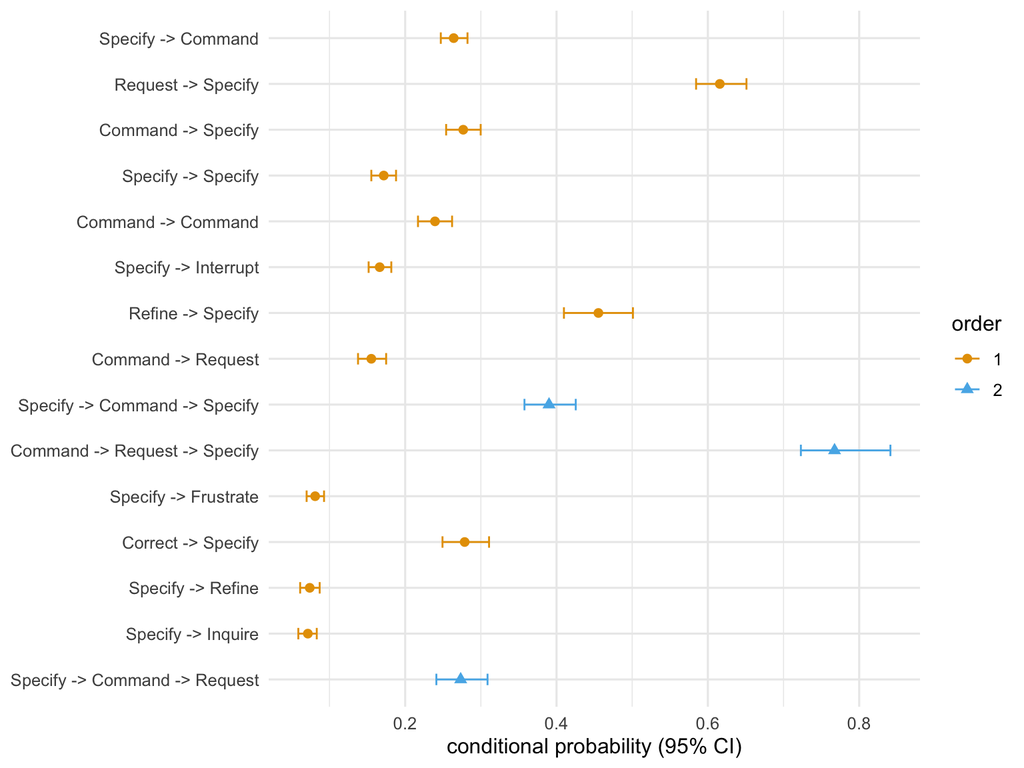

```r
plot(bs, top = 15)
```

## Did the rules change between the early and late period?

```r
early <- subset(human_long, session_date < "2026-02-21")
late  <- subset(human_long, session_date >= "2026-02-21")
cmp <- compare_hon(early, late, action = "code", actor = "session_id",
                   time = "timestamp", n_perm = 500, max_order = 3,
                   min_freq = 5, seed = 12, parallel = TRUE, n_cores = 2,
                   names = c("early", "late"))
cmp
```

```
## HON comparison: early (210 sequences) vs late (217 sequences)
##   828 pooled rule edges, 500 permutations
##   Global weighted |diff|: 0.0875, p = 0.001996
##   Significant edges (BH, alpha = 0.05): 0
##   Tidy table: as.data.frame(x); significant only: as.data.frame(x, significant = TRUE)
```

```r
summary(cmp)
```

```
##   order n_edges n_significant max_abs_diff
## 1     1      81             0   0.08712979
## 2     2     451             0   1.00000000
## 3     3     296             0   1.00000000
```

The two results disagree on purpose, and reading them together is the point of the design. The global test is unambiguous: the pooled-count-weighted mean absolute difference is 0.0875, and only 1 of 501 permutations reaches it (p = 0.002) — the rule structure did shift between the periods. Yet not a single one of the 828 edges is individually significant after Benjamini–Hochberg adjustment. The shift is *diffuse*: many small, consistent differences spread across the rule set, none large enough to survive 828-way multiplicity on its own. The extreme per-edge differences (absolute difference 1.0 at orders 2–3) are contexts observed in only one period with small counts — exactly the edges a permutation null neutralizes.

The decisive report is therefore: the interaction rules changed over time as a whole, and no single rule should be named as the locus of that change. Naming one anyway — picking the largest difference and reporting it despite its adjusted p-value — is the multiple-testing error this verb’s two-level design exists to prevent.

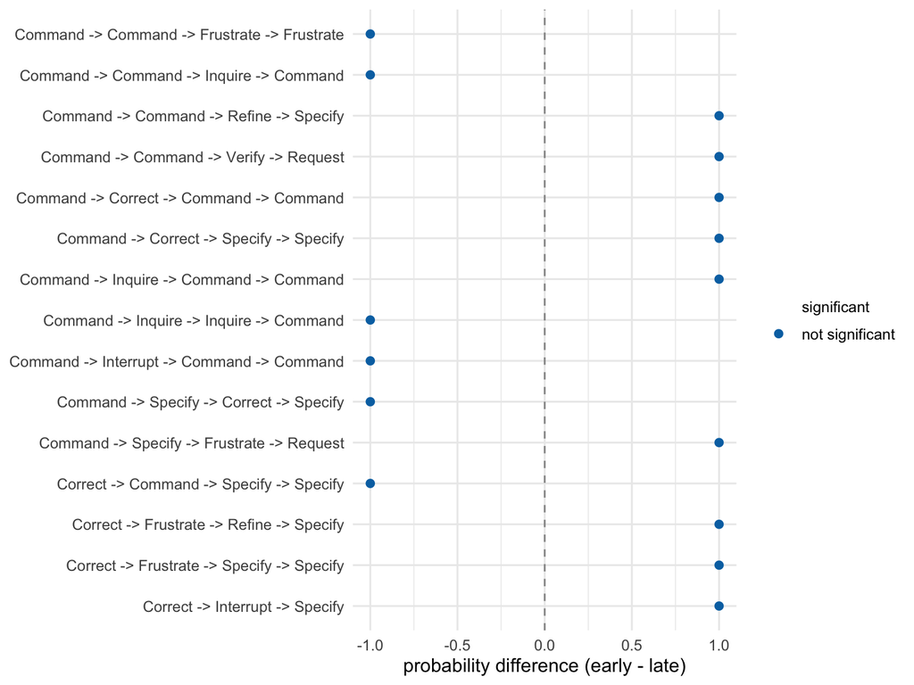

```r
plot(cmp, top = 15)
```

The difference plot confirms the reading: the largest differences all plot in the not-significant encoding, and no edge separates from the pack.

## When to use which

- **`bootstrap_hon()`** — one cohort, and the question is whether the extracted rules and their probabilities are stable enough to report. Filter with `as.data.frame(x, order_min = 2, min_support = 0.9)` before citing individual higher-order rules; report interval widths, not just point probabilities.
- **`compare_hon()`** — two cohorts, and the question is whether the rule structure differs. Read the global test first; per-edge findings only from the BH-adjusted column. A significant global with no significant edges is a finding, not a failure: the difference is distributed.
- **`markov_order_test()`** — the prior, coarser question: is there any memory beyond order 1 at all, as a single global decision.
- **`path_dependence()`** — a descriptive per-context diagnostic of where memory concentrates, without inference; useful for choosing contexts to examine before the bootstrap.

## References

- Xu, J., Wickramarathne, T. L., & Chawla, N. V. (2016). Representing higher-order dependencies in networks. *Science Advances*, 2(5), e1600028.
- Efron, B., & Tibshirani, R. J. (1993). *An Introduction to the Bootstrap*. Chapman & Hall.
- Good, P. (2005). *Permutation, Parametric and Bootstrap Tests of Hypotheses* (3rd ed.). Springer.
- Benjamini, Y., & Hochberg, Y. (1995). Controlling the false discovery rate. *JRSS B*, 57(1), 289–300.